# Midterm 1 Exam - 70 Points

## Case Study: IMDB Moving Rating Analysis

In this analysis we would like to explore the relationships between various attributes of popular movies.

IMDB.com is a well-known website that lists useful information about movies and TV shows and enables users to rate them. The data in the **imdb_popular.csv** file contains the following information about some of the most popular **movies** and **tv shows** listed on IMDB.

- **Name**: name of the tv series or movie
- **Date**: movie release year
- **Rate**: IMDB's rating
- **Genre**
- **Duration**: Duration of the episode/movie
- **Type**: Whether it's a 'Film' or 'Series'
- **Certificate**: The rating letter ('G', 'PG', 'PG-13', 'R', etc)
- **Nudity**: The level of nudity in the film/series
- **Violence**: The level of violence in the film/series
- **Profanity**: The level of profanity in the film/series
- **Alcohol**: The level of alcohol use in the film/series
- **Frightening**: The level of frightening content in the film/series

### Research Goals:

In this study we will explore the following research goals.

1. Clean the dataset and manipulate it into a form that best helps us meet our other research goals.
2. Find the top rated movies for each genre.
3. Explore the relationship between the genre of the movie and IMDB movie ratings.
4. Explore the relationship between the genre of the movies and the level of sensitive content in the movies.
5. Perform preliminary analysis on the dataset that may help data scientists at Neflix make useful recommendations to different types of users.

## Points

| Problem | Points |
| --- | --- |
| 1.1 | 5 |
| 1.2 | 0.5 |
| 1.3 | 2 |
| 1.4.1 | 2.5 |
| 1.4.2 | 2.5 |
| 1.4.3 | 3 |
| 1.5 | 0.5 |
| 2.1.1 | 2.5 |
| 2.1.2 | 3 |
| 2.2.1 | 2.5 |
| 2.2.2 | 3.5 |
| 3.1 | 3 |
| 3.2 | 1 |
| 4.1 | 3 |
| 4.2 | 3 |
| 4.3 | 2.5 |
| 5.1 | 2 |
| 5.2 | 4 |
| 5.3 | 1.75 |
| 5.4.1 | 2 |
| 5.4.2 | 0.75 |
| 6.1 | 4.5 |
| 6.2 | 1 |
| 7.1.1 | 1.5 |
| 7.1.2 | 1.5 |
| 7.2.1 | 3.5 |
| 7.2.2 | 1 |
| 8 | 1.5 |
| 9.1 | 3 |
| 9.2 | 2 |

## UIUC Academic Integrity Policy

## WRITE YOUR FULL NAME BELOW BEFORE BEGINNING

This is a an open notes takehome exam. **However, you are not allowed to discuss this exam, open someone else's exam, or share/send your exam to anyone else except for Dr. Ellison until after the 24 hour exam period is over.**

By writing your full name in the textbox below you are indicating that you have read and are aware of the academic dishonesty policies http://courses.las.illinois.edu/fall2022/stat207/syllabus.html which indicates that evidence of cheating on the exam results in an automatic F in the course.

Sabir Rahman

### Imports

```python
import pandas as pd
import numpy as np
import seaborn as sns
import matplotlib.pyplot as plt

from scipy.stats import bernoulli
from scipy.stats import binom
from scipy.stats import norm
```

## 1. Data Cleaning and Processing

### 1.1. Missing Value Detection and Cleaning

We plan to analyze all of variables in this dataset. In order to ensure that our subsequent functions work appropriately on these variables, you should do the following.

1. Identify any values (if any) **in your numerical variables** that have been encoded in the csv to represent a **missing value**.
2. Make sure that the values in each of your numerical variables are represented as numerical values (either float64 or int64 object types). If not, fix this using the methods we discussed in class.
3. Delete any rows in your dataframe that have missing values. Remember, some "missing values", in the way that they're currently encoded in the csv may not be initially detectable by Python. It is your job to figure out what these missing values are represented by and make it so Python does detect them.
4. **Delete any rows that have a missing value that you detected.**
5. **Discuss how many rows that you dropped.**
6. **Display the first five rows of your final cleaned dataframe.**

```python
missing_values = ["missing"]
df = pd.read_csv('imdb_popular.csv', na_values = missing_values)
df
```

|  | Name | Date | Rate | Genre | Duration | Type | Certificate | Nudity | Violence | Profanity | Alcohol | Frightening |
| --- | --- | --- | --- | --- | --- | --- | --- | --- | --- | --- | --- | --- |
| 0 | No Time to Die | 2021 | 7.6 | Action | 163.0 | Film | PG-13 | Mild | Moderate | Mild | Mild | Moderate |
| 1 | The Guilty | 2021 | 6.3 | Crime | 90.0 | Film | R | None | None | Severe | None | Moderate |
| 2 | The Many Saints of Newark | 2021 | 6.4 | Crime | 120.0 | Film | R | Moderate | Severe | Severe | Moderate | Moderate |
| 3 | Venom: Let There Be Carnage | 2021 | 6.4 | Action | 97.0 | Film | PG-13 | None | Moderate | Moderate | Mild | Moderate |
| 4 | Dune | 2021 | 8.3 | Action | 155.0 | Film | PG-13 | None | Moderate | None | Mild | Moderate |
| ... | ... | ... | ... | ... | ... | ... | ... | ... | ... | ... | ... | ... |
| 6173 | The Human Centipede II (Full Sequence) | 2011 | 3.8 | Horror | 91.0 | Film | Not Rated | Severe | Severe | Severe | Mild | Severe |
| 6174 | Double Indemnity | 1944 | 8.3 | Crime | 107.0 | Film | Passed | None | Mild | None | Mild | Mild |
| 6175 | Before the Devil Knows You're Dead | 2007 | 7.3 | Crime | 117.0 | Film | R | Severe | Moderate | Severe | Severe | Severe |
| 6176 | Queen Bees | 2021 | 6.0 | Comedy | 100.0 | Film | PG-13 | None | None | Mild | Moderate | None |
| 6177 | Death Race | 2008 | 6.3 | Action | 105.0 | Film | R | Mild | Severe | Severe | Mild | Moderate |

6178 rows × 12 columns

```python
df.dtypes
```

```
Name            object
Date             int64
Rate           float64
Genre           object
Duration       float64
Type            object
Certificate     object
Nudity          object
Violence        object
Profanity       object
Alcohol         object
Frightening     object
dtype: object
```

```python
df['Frightening'].unique()
```

```
array(['Moderate', 'None', 'Mild', 'No Rate', 'Severe'], dtype=object)
```

```python
df = df.dropna()
df
```

|  | Name | Date | Rate | Genre | Duration | Type | Certificate | Nudity | Violence | Profanity | Alcohol | Frightening |
| --- | --- | --- | --- | --- | --- | --- | --- | --- | --- | --- | --- | --- |
| 0 | No Time to Die | 2021 | 7.6 | Action | 163.0 | Film | PG-13 | Mild | Moderate | Mild | Mild | Moderate |
| 1 | The Guilty | 2021 | 6.3 | Crime | 90.0 | Film | R | None | None | Severe | None | Moderate |
| 2 | The Many Saints of Newark | 2021 | 6.4 | Crime | 120.0 | Film | R | Moderate | Severe | Severe | Moderate | Moderate |
| 3 | Venom: Let There Be Carnage | 2021 | 6.4 | Action | 97.0 | Film | PG-13 | None | Moderate | Moderate | Mild | Moderate |
| 4 | Dune | 2021 | 8.3 | Action | 155.0 | Film | PG-13 | None | Moderate | None | Mild | Moderate |
| ... | ... | ... | ... | ... | ... | ... | ... | ... | ... | ... | ... | ... |
| 6173 | The Human Centipede II (Full Sequence) | 2011 | 3.8 | Horror | 91.0 | Film | Not Rated | Severe | Severe | Severe | Mild | Severe |
| 6174 | Double Indemnity | 1944 | 8.3 | Crime | 107.0 | Film | Passed | None | Mild | None | Mild | Mild |
| 6175 | Before the Devil Knows You're Dead | 2007 | 7.3 | Crime | 117.0 | Film | R | Severe | Moderate | Severe | Severe | Severe |
| 6176 | Queen Bees | 2021 | 6.0 | Comedy | 100.0 | Film | PG-13 | None | None | Mild | Moderate | None |
| 6177 | Death Race | 2008 | 6.3 | Action | 105.0 | Film | R | Mild | Severe | Severe | Mild | Moderate |

5846 rows × 12 columns

```python
df.head()
```

|  | Name | Date | Rate | Genre | Duration | Type | Certificate | Nudity | Violence | Profanity | Alcohol | Frightening |
| --- | --- | --- | --- | --- | --- | --- | --- | --- | --- | --- | --- | --- |
| 0 | No Time to Die | 2021 | 7.6 | Action | 163.0 | Film | PG-13 | Mild | Moderate | Mild | Mild | Moderate |
| 1 | The Guilty | 2021 | 6.3 | Crime | 90.0 | Film | R | None | None | Severe | None | Moderate |
| 2 | The Many Saints of Newark | 2021 | 6.4 | Crime | 120.0 | Film | R | Moderate | Severe | Severe | Moderate | Moderate |
| 3 | Venom: Let There Be Carnage | 2021 | 6.4 | Action | 97.0 | Film | PG-13 | None | Moderate | Moderate | Mild | Moderate |
| 4 | Dune | 2021 | 8.3 | Action | 155.0 | Film | PG-13 | None | Moderate | None | Mild | Moderate |

```python
6178 - 5846
```

```
332
```

332 rows were dropped after cleaning the dataset

### 1.2. Checking your data cleaning.

Calculate the average of each of your numerical variables in this cleaned dataset.

*Hint: You will not be able to succesfully run this code if you did not appropriately clean your dataframe.*

```python
date_average = df["Date"].mean()
date_average
```

```
2005.605713308245
```

```python
rate_average = df["Rate"].mean()
rate_average
```

```
6.8759322613753
```

```python
duration_average = df["Duration"].mean()
duration_average
```

```
94.5078686281218
```

### 1.3. Exploring Just the Movies

In this analysis, we'd like to just focus on just the 'Film' rows, and not the 'Series' rows. Create a new dataframe that is just comprised of films.

```python
df_films = df[df["Type"] == "Film"].reset_index(drop=True)
df_films
```

|  | Name | Date | Rate | Genre | Duration | Type | Certificate | Nudity | Violence | Profanity | Alcohol | Frightening |
| --- | --- | --- | --- | --- | --- | --- | --- | --- | --- | --- | --- | --- |
| 0 | No Time to Die | 2021 | 7.6 | Action | 163.0 | Film | PG-13 | Mild | Moderate | Mild | Mild | Moderate |
| 1 | The Guilty | 2021 | 6.3 | Crime | 90.0 | Film | R | None | None | Severe | None | Moderate |
| 2 | The Many Saints of Newark | 2021 | 6.4 | Crime | 120.0 | Film | R | Moderate | Severe | Severe | Moderate | Moderate |
| 3 | Venom: Let There Be Carnage | 2021 | 6.4 | Action | 97.0 | Film | PG-13 | None | Moderate | Moderate | Mild | Moderate |
| 4 | Dune | 2021 | 8.3 | Action | 155.0 | Film | PG-13 | None | Moderate | None | Mild | Moderate |
| ... | ... | ... | ... | ... | ... | ... | ... | ... | ... | ... | ... | ... |
| 4292 | The Human Centipede II (Full Sequence) | 2011 | 3.8 | Horror | 91.0 | Film | Not Rated | Severe | Severe | Severe | Mild | Severe |
| 4293 | Double Indemnity | 1944 | 8.3 | Crime | 107.0 | Film | Passed | None | Mild | None | Mild | Mild |
| 4294 | Before the Devil Knows You're Dead | 2007 | 7.3 | Crime | 117.0 | Film | R | Severe | Moderate | Severe | Severe | Severe |
| 4295 | Queen Bees | 2021 | 6.0 | Comedy | 100.0 | Film | PG-13 | None | None | Mild | Moderate | None |
| 4296 | Death Race | 2008 | 6.3 | Action | 105.0 | Film | R | Mild | Severe | Severe | Mild | Moderate |

4297 rows × 12 columns

### 1.4. More Cleaning

To simplify this analysis, let's perform some more cleaning below.

#### 1.4.1. Only Content Variables with Ratings

Each of the sensitive content variables (Nudity, Violence, Profanity, Alcohol, Frightening) have some values listed as 'No Rate'. For the purpose of this analysis, we will interpret these too as missing values. For each of the sensitive content variables, get rid of any rows that have a 'No Rate' value.

```python
df_films = df_films[df_films["Nudity"] != "No Rate"]
df_films = df_films[df_films["Violence"] != "No Rate"]
df_films = df_films[df_films["Profanity"] != "No Rate"]
df_films = df_films[df_films["Alcohol"] != "No Rate"]
df_films = df_films[df_films["Frightening"] != "No Rate"]
df_films
```

|  | Name | Date | Rate | Genre | Duration | Type | Certificate | Nudity | Violence | Profanity | Alcohol | Frightening |
| --- | --- | --- | --- | --- | --- | --- | --- | --- | --- | --- | --- | --- |
| 0 | No Time to Die | 2021 | 7.6 | Action | 163.0 | Film | PG-13 | Mild | Moderate | Mild | Mild | Moderate |
| 1 | The Guilty | 2021 | 6.3 | Crime | 90.0 | Film | R | None | None | Severe | None | Moderate |
| 2 | The Many Saints of Newark | 2021 | 6.4 | Crime | 120.0 | Film | R | Moderate | Severe | Severe | Moderate | Moderate |
| 3 | Venom: Let There Be Carnage | 2021 | 6.4 | Action | 97.0 | Film | PG-13 | None | Moderate | Moderate | Mild | Moderate |
| 4 | Dune | 2021 | 8.3 | Action | 155.0 | Film | PG-13 | None | Moderate | None | Mild | Moderate |
| ... | ... | ... | ... | ... | ... | ... | ... | ... | ... | ... | ... | ... |
| 4292 | The Human Centipede II (Full Sequence) | 2011 | 3.8 | Horror | 91.0 | Film | Not Rated | Severe | Severe | Severe | Mild | Severe |
| 4293 | Double Indemnity | 1944 | 8.3 | Crime | 107.0 | Film | Passed | None | Mild | None | Mild | Mild |
| 4294 | Before the Devil Knows You're Dead | 2007 | 7.3 | Crime | 117.0 | Film | R | Severe | Moderate | Severe | Severe | Severe |
| 4295 | Queen Bees | 2021 | 6.0 | Comedy | 100.0 | Film | PG-13 | None | None | Mild | Moderate | None |
| 4296 | Death Race | 2008 | 6.3 | Action | 105.0 | Film | R | Mild | Severe | Severe | Mild | Moderate |

4000 rows × 12 columns

#### 1.4.2. Most Well Known Certificates

Let's also just keep the most common known certificate levels in this dataset: **'R','PG-13', 'PG', 'G'**. Drop all rows that do not have one of these certificate levels.

```python
df_films["Certificate"].unique()
```

```
array(['PG-13', 'R', 'TV-MA', 'PG', 'TV-PG', 'TV-14', 'Not Rated', 'TV-G',
       'E', 'NC-17', '(Banned)', 'Unrated', 'Approved', 'G', 'GP',
       'Passed', 'M', 'X', 'TV-Y7', 'M/PG'], dtype=object)
```

```python
df_films = df_films[df_films["Certificate"] != "TV-MA"]
df_films = df_films[df_films["Certificate"] != "TV-PG"]
df_films = df_films[df_films["Certificate"] != "TV-14"]
df_films = df_films[df_films["Certificate"] != "Not Rated"]
df_films = df_films[df_films["Certificate"] != "TV-G"]
df_films = df_films[df_films["Certificate"] != "E"]
df_films = df_films[df_films["Certificate"] != "NC-17"]
df_films = df_films[df_films["Certificate"] != "(Banned)"]
df_films = df_films[df_films["Certificate"] != "Unrated"]
df_films = df_films[df_films["Certificate"] != "Approved"]
df_films = df_films[df_films["Certificate"] != "GP"]
df_films = df_films[df_films["Certificate"] != "Passed"]
df_films = df_films[df_films["Certificate"] != "M"]
df_films = df_films[df_films["Certificate"] != "X"]
df_films = df_films[df_films["Certificate"] != "TV-Y7"]
df_films = df_films[df_films["Certificate"] != "M/PG"]
df_films
```

|  | Name | Date | Rate | Genre | Duration | Type | Certificate | Nudity | Violence | Profanity | Alcohol | Frightening |
| --- | --- | --- | --- | --- | --- | --- | --- | --- | --- | --- | --- | --- |
| 0 | No Time to Die | 2021 | 7.6 | Action | 163.0 | Film | PG-13 | Mild | Moderate | Mild | Mild | Moderate |
| 1 | The Guilty | 2021 | 6.3 | Crime | 90.0 | Film | R | None | None | Severe | None | Moderate |
| 2 | The Many Saints of Newark | 2021 | 6.4 | Crime | 120.0 | Film | R | Moderate | Severe | Severe | Moderate | Moderate |
| 3 | Venom: Let There Be Carnage | 2021 | 6.4 | Action | 97.0 | Film | PG-13 | None | Moderate | Moderate | Mild | Moderate |
| 4 | Dune | 2021 | 8.3 | Action | 155.0 | Film | PG-13 | None | Moderate | None | Mild | Moderate |
| ... | ... | ... | ... | ... | ... | ... | ... | ... | ... | ... | ... | ... |
| 4288 | Alvin and the Chipmunks: The Road Chip | 2015 | 5.0 | Animation | 92.0 | Film | PG | Mild | Mild | Mild | Mild | Mild |
| 4290 | How High | 2001 | 6.3 | Comedy | 93.0 | Film | R | Moderate | Mild | Severe | Severe | None |
| 4294 | Before the Devil Knows You're Dead | 2007 | 7.3 | Crime | 117.0 | Film | R | Severe | Moderate | Severe | Severe | Severe |
| 4295 | Queen Bees | 2021 | 6.0 | Comedy | 100.0 | Film | PG-13 | None | None | Mild | Moderate | None |
| 4296 | Death Race | 2008 | 6.3 | Action | 105.0 | Film | R | Mild | Severe | Severe | Mild | Moderate |

3525 rows × 12 columns

```python
df_films["Certificate"].unique()
```

```
array(['PG-13', 'R', 'PG', 'G'], dtype=object)
```

#### 1.4.3. Most Common Genres

To simplify this analysis, let's filter our dataset to be comprised of just the **top 5 most common genres** in this dataset.

Create your filtered dataframe below.

```python
df_top_genres = df_films.groupby("Genre").count().reset_index()
df_top_genres = df_top_genres.sort_values(by=["Name"], ascending=False)
df_top_genres.head()
```

|  | Genre | Name | Date | Rate | Duration | Type | Certificate | Nudity | Violence | Profanity | Alcohol | Frightening |
| --- | --- | --- | --- | --- | --- | --- | --- | --- | --- | --- | --- | --- |
| 0 | Action | 1057 | 1057 | 1057 | 1057 | 1057 | 1057 | 1057 | 1057 | 1057 | 1057 | 1057 |
| 4 | Comedy | 735 | 735 | 735 | 735 | 735 | 735 | 735 | 735 | 735 | 735 | 735 |
| 6 | Drama | 582 | 582 | 582 | 582 | 582 | 582 | 582 | 582 | 582 | 582 | 582 |
| 10 | Horror | 250 | 250 | 250 | 250 | 250 | 250 | 250 | 250 | 250 | 250 | 250 |
| 5 | Crime | 231 | 231 | 231 | 231 | 231 | 231 | 231 | 231 | 231 | 231 | 231 |

```python
df_films["Genre"].unique()
```

```
array(['Action', 'Crime', 'Horror', 'Animation', 'Drama', 'Comedy',
       'Adventure', 'Biography', 'Mystery', 'Fantasy', 'Thriller',
       'Western', 'Family', 'Musical', 'Sci-Fi', 'History', 'Romance'],
      dtype=object)
```

```python
df_films = df_films[df_films["Genre"] != "Animation"]
df_films = df_films[df_films["Genre"] != "Adventure"]
df_films = df_films[df_films["Genre"] != "Biography"]
df_films = df_films[df_films["Genre"] != "Mystery"]
df_films = df_films[df_films["Genre"] != "Fantasy"]
df_films = df_films[df_films["Genre"] != "Thriller"]
df_films = df_films[df_films["Genre"] != "Western"]
df_films = df_films[df_films["Genre"] != "Family"]
df_films = df_films[df_films["Genre"] != "Musical"]
df_films = df_films[df_films["Genre"] != "Sci-Fi"]
df_films = df_films[df_films["Genre"] != "History"]
df_films = df_films[df_films["Genre"] != "Romance"]
df_films
```

|  | Name | Date | Rate | Genre | Duration | Type | Certificate | Nudity | Violence | Profanity | Alcohol | Frightening |
| --- | --- | --- | --- | --- | --- | --- | --- | --- | --- | --- | --- | --- |
| 0 | No Time to Die | 2021 | 7.6 | Action | 163.0 | Film | PG-13 | Mild | Moderate | Mild | Mild | Moderate |
| 1 | The Guilty | 2021 | 6.3 | Crime | 90.0 | Film | R | None | None | Severe | None | Moderate |
| 2 | The Many Saints of Newark | 2021 | 6.4 | Crime | 120.0 | Film | R | Moderate | Severe | Severe | Moderate | Moderate |
| 3 | Venom: Let There Be Carnage | 2021 | 6.4 | Action | 97.0 | Film | PG-13 | None | Moderate | Moderate | Mild | Moderate |
| 4 | Dune | 2021 | 8.3 | Action | 155.0 | Film | PG-13 | None | Moderate | None | Mild | Moderate |
| ... | ... | ... | ... | ... | ... | ... | ... | ... | ... | ... | ... | ... |
| 4287 | Daddy Day Care | 2003 | 5.6 | Comedy | 92.0 | Film | PG | None | Mild | Mild | None | None |
| 4290 | How High | 2001 | 6.3 | Comedy | 93.0 | Film | R | Moderate | Mild | Severe | Severe | None |
| 4294 | Before the Devil Knows You're Dead | 2007 | 7.3 | Crime | 117.0 | Film | R | Severe | Moderate | Severe | Severe | Severe |
| 4295 | Queen Bees | 2021 | 6.0 | Comedy | 100.0 | Film | PG-13 | None | None | Mild | Moderate | None |
| 4296 | Death Race | 2008 | 6.3 | Action | 105.0 | Film | R | Mild | Severe | Severe | Mild | Moderate |

2855 rows × 12 columns

### 1.5. Final Cleaned Dataset

We will use this final resulting dataframe from 1.4.3 throughout the rest of the analysis. How many rows are in this remaining dataset?

There are 2,855 rows remaining

## 2. Exploring Movie Ratings

Next we would like to learn more about the general ratings of these movies in the dataset.

### 2.1. Movie Rating Distribution

#### 2.1.1. Histogram and Boxplot

Plot a histogram showing the distribution of movie ratings for all remaining movies in this dataset. Make sure you give an appropriate title, x-axis label, and y-axis label.

Also plot a boxplot showing the distribution of movie ratings for all remaining movies in this dataset. Make sure you give an appropriate title.

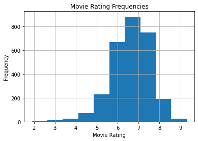

```python
df_films["Rate"].hist()
plt.xlabel("Movie Rating")
plt.ylabel("Frequency")
plt.title("Movie Rating Frequencies")
plt.show()
```

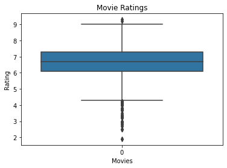

```python
sns.boxplot(data = df_films["Rate"])
plt.xlabel("Movies")
plt.ylabel("Rating")
plt.title("Movie Ratings")
plt.show()
```

#### 2.1.2. Describing the Distribution

1. Describe the shape of the movie ratings distribution.
2. Calculate an *appropriate* measure of center and spread for this distribution. Why are these measure of center and spread appropriate?
3. Describe the nature of any outliers in this distribution of ratings.
1. The distribution of the movie ratings is unimodal and left skewed.
2. An appropriate measure of center is 6.7 and an appropriate measure of spread is 1.2000000000000002. I used the median for the measure of center and IQR for the spread since the distribution is skewed.
3. The outliers in this distribution are for movies that are rated very highly because they are very good or rated very low because they are really bad, which makes sense

```python
df_films["Rate"].median()
```

```
6.7
```

```python
df_films["Rate"].quantile(.75) - df_films["Rate"].quantile(.25)
```

```
1.2000000000000002
```

### 2.2. Highest Rated Movies for Each Genre

Next, we would ultimately like to find the **rating** and the **name** of the highest rated movie(s) for each genre in this dataset.

#### 2.2.1 Highest Movie Ratings for Each Genre

Create a dataframe below that shows the highest movie rating for each genre in the dataset. Your final dataframe should have the following specifications.

1. Just two columns: **genre** and **rating**
2. An **index with numbers** (not genre types)
3. Sorted by the rating column, in descending order.

Show this dataframe.

```python
df_films_highest_rated = df_films.groupby("Genre").max().reset_index()
df_films_highest_rated = df_films_highest_rated.iloc[:, [0,3]]
df_films_highest_rated= df_films_highest_rated.sort_values(by=["Rate"], ascending=False).reset_index(drop=True)
df_films_highest_rated
```

|  | Genre | Rate |
| --- | --- | --- |
| 0 | Drama | 9.3 |
| 1 | Crime | 9.2 |
| 2 | Action | 9.0 |
| 3 | Comedy | 8.6 |
| 4 | Horror | 8.5 |

#### 2.2.2. Rating and Name of the Highest Rated Movie(s) for Each Genre

Finally, find the **rating** AND the **name** of the highest rated movie(s) for each **genre**.

Your final dataframe that you display should contain just the **name**, **rating**, and **genre** variables.

```python
df_top_rated = df_films.groupby("Genre").max().reset_index()
df_top_rated = df_top_rated.sort_values(by=["Rate"], ascending=False).reset_index(drop=True)
df_top_rated = df_top_rated.iloc[:, [0, 1, 3]]
df_top_rated
```

|  | Genre | Name | Rate |
| --- | --- | --- | --- |
| 0 | Drama | Ôdishon | 9.3 |
| 1 | Crime | Zodiac | 9.2 |
| 2 | Action | xXx: Return of Xander Cage | 9.0 |
| 3 | Comedy | Zoolander | 8.6 |
| 4 | Horror | À l'intérieur | 8.5 |

## 3. Relationships between Movie Ratings and what the Movie is About

Next, we would like to explore the relationship between the following pairs of variables.

- movie rating and genre
- movie rating and certificate
- movie rating and nudity level
- movie rating and violence level
- movie rating and profanity level
- movie rating and alcohol level
- movie rating and frightening level

### 3.1. Strongest Relationship

**Which one of these 7 pairs of variables exhibits the strongest association?**

- Explain and show your work.
- Your explanation should include 7 side-by-side boxplots visualizations, one for each pair.
- Make sure any plot you use is appropriately titled and has appropriate x- and y-axis labels.

The association between movie ratings and genre has the strongest association out of the 7 pairs since there is the least overlap for the box plots.

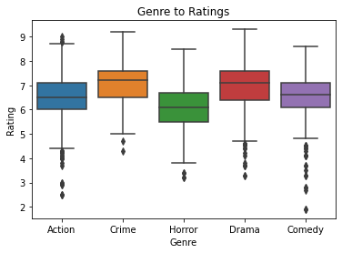

```python
sns.boxplot(data = df_films, x = "Genre", y = "Rate")
plt.xlabel("Genre")
plt.ylabel("Rating")
plt.title("Genre to Ratings")
plt.show()
```

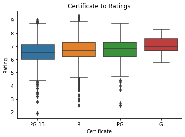

```python
sns.boxplot(data = df_films, x = "Certificate", y = "Rate")
plt.xlabel("Certificate")
plt.ylabel("Rating")
plt.title("Certificate to Ratings")
plt.show()
```

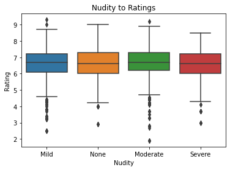

```python
sns.boxplot(data = df_films, x = "Nudity", y = "Rate")
plt.xlabel("Nudity")
plt.ylabel("Rating")
plt.title("Nudity to Ratings")
plt.show()
```

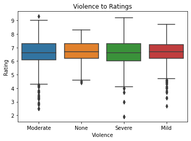

```python
sns.boxplot(data = df_films, x = "Violence", y = "Rate")
plt.xlabel("Violence")
plt.ylabel("Rating")
plt.title("Violence to Ratings")
plt.show()
```

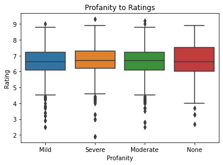

```python
sns.boxplot(data = df_films, x = "Profanity", y = "Rate")
plt.xlabel("Profanity")
plt.ylabel("Rating")
plt.title("Profanity to Ratings")
plt.show()
```

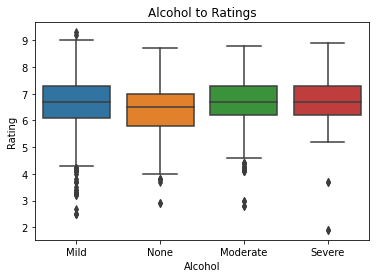

```python
sns.boxplot(data = df_films, x = "Alcohol", y = "Rate")
plt.xlabel("Alcohol")
plt.ylabel("Rating")
plt.title("Alcohol to Ratings")
plt.show()
```

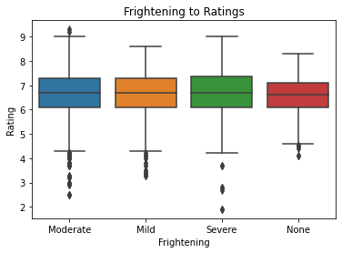

```python
sns.boxplot(data = df_films, x = "Frightening", y = "Rate")
plt.xlabel("Frightening")
plt.ylabel("Rating")
plt.title("Frightening to Ratings")
plt.show()
```

### 3.2. Strength of the Relationship

Would you say that this variable pairing that you selected in 3.1. demonstrates a *strong* association between the two variables? Why or why not?

I wouldn't say the variable pairing determines a strong association because there is still a bit of overlap between the boxplots but not as much as the other boxplots.

## 4. Relationships between Movie Genre and Sensitivity Attributes

### 4.1. Visualizing the Relationships

Next, we would like to explore the relationships between the following pairs of variables.

- genre and certificate
- genre and nudity level
- genre and violence level
- genre and profanity level
- genre and alcohol level
- genre and frightening level

For each of the 6 pairs of categorical variables above, create an appropriate plot that visualizes the relationship between these two variables.

- In a given plot, there should be a bar for each combination of levels of the two corresponding categorical variables.
- Make sure your plots have appropriate titles.

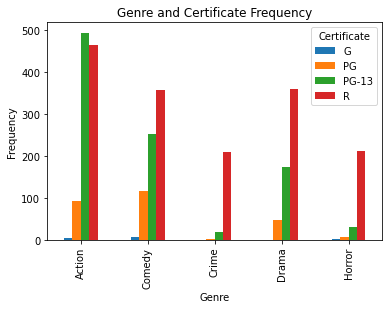

```python
a = df_films.groupby(["Genre", "Certificate"]).size()
a = a.unstack()

a.plot(xlabel = "Genre", ylabel = "Frequency", title = "Genre and Certificate Frequency", kind = "bar")
```

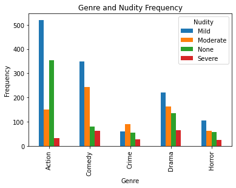

```python
a = df_films.groupby(["Genre", "Nudity"]).size()
a = a.unstack()

a.plot(xlabel = "Genre", ylabel = "Frequency", title = "Genre and Nudity Frequency", kind = "bar")
```

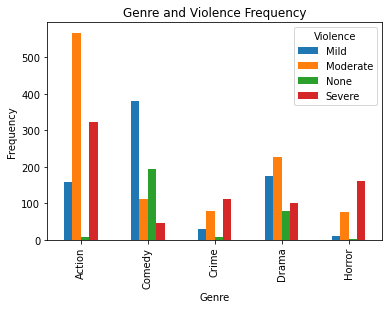

```python
a = df_films.groupby(["Genre", "Violence"]).size()
a = a.unstack()

a.plot(xlabel = "Genre", ylabel = "Frequency", title = "Genre and Violence Frequency", kind = "bar")
```

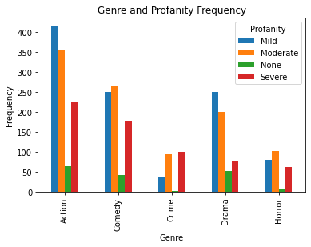

```python
a = df_films.groupby(["Genre", "Profanity"]).size()
a = a.unstack()

a.plot(xlabel = "Genre", ylabel = "Frequency", title = "Genre and Profanity Frequency", kind = "bar")
```

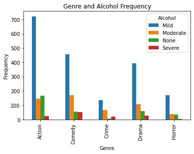

```python
a = df_films.groupby(["Genre", "Alcohol"]).size()
a = a.unstack()

a.plot(xlabel = "Genre", ylabel = "Frequency", title = "Genre and Alcohol Frequency", kind = "bar")
```

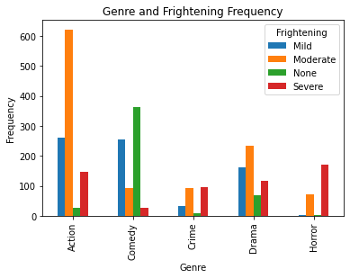

```python
a = df_films.groupby(["Genre", "Frightening"]).size()
a = a.unstack()

a.plot(xlabel = "Genre", ylabel = "Frequency", title = "Genre and Frightening Frequency", kind = "bar")
```

### 4.2. Learning More

Your plots above *might* be useful in helping you answer some of the questions below, depending on how you constructed them. However, you will have to create at least one additional plot to help you answer some of these questions.

### 4.3. Assessing Associations

For each of the pairs of categorical variables listed below, state whether there is an association or not. Explain.

- genre and certificate
- genre and nudity level
- genre and violence level
- genre and profanity level
- genre and alcohol level
- genre and frightening level

Genre and Certificate have an association because there isn't a lot of overlap.

Genre and Nudity Level have an association because there isn't a lot of overlap.

Genre and Profanity Level don't have an association because there is a lot of overlap.

Genre and Alcohol Level have an association because there isn't a lot of overlap.

Genre and Frightening Level have an association because there isn't a lot of overlap.

## 5. Violent Content Moderation for Netflix Accounts with Children

Suppose that you are a data scientist that works at Netflix. You would like to develop movie recommendation strategies to advertise to parents who happen to have small children in the house. In particular, this would be a service that recommends a random selection of top IMDB rated movies of a particular genre to parent account holders, that also tries to cut down on the amount of movies with severe violence suggested in the selection.

### 5.1. Comedies with Severe Violence

First, what is the probability that a randomly selected comedy in this dataset will have severe violence?

```python
len(df_films[df_films["Violence"] == "Severe"]) / len(df_films)
```

```
0.26024518388791595
```

### 5.2 Random Selection of 10 Comedy Movies

Suppose that your proposed recommendation strategy will display a random selection of 10 top rated IMDB movies for a given genre. For this new service for houses with small children, Netflix would like to offer a guarantee that no more than 1 of a given random selection's movies will contain a movie with severe violence.

Without any interventions from the data scientist team, what is the probability that a random sample of 10 comedy movies from this dataset will not meet this guarantee?

*Note: You should assume that the population of comedy movies in this dataset is sufficiently much large with respect to a sample of size 10*.

```python
df_comedy = df_films[df_films["Genre"] == "Comedy"].reset_index(drop=True)
cov = len(df_comedy[df_comedy["Violence"] == "Severe"]) / len(df_comedy)
x = binom.pmf(n = 10, p = cov, k =1)
x
```

```
0.35279336700793135
```

### 5.3. Expected Average Number of Severely Violent Comedies in Many, Many Recommended Samples

If the Netflix team were to create many, many random samples of 10 comedy movies, on average what number of the movies in each of the samples would have severe violence?

#### 5.4.1 Generating Random Variable Values

Next, simulate this 10 comedy random sample 40 times, and for each of these simulated random samples show $X=$ the number of comedies in the sample that had severe violence.

**For full credit, you should do this in just 1-3 lines of code. In other words, there is a function that will do all this for you.**

**Put each of these X values for the 40 simulated random samples in a dataframe.**

```python
data = []
for i in range(40):
    data.append( binom.rvs(n=10, p=cov, size = 1) )
df_rcs = pd.DataFrame(data)
df_rcs
```

|  | 0 |
| --- | --- |
| 0 | 0 |
| 1 | 2 |
| 2 | 0 |
| 3 | 1 |
| 4 | 1 |
| 5 | 0 |
| 6 | 2 |
| 7 | 1 |
| 8 | 1 |
| 9 | 2 |
| 10 | 1 |
| 11 | 2 |
| 12 | 0 |
| 13 | 0 |
| 14 | 2 |
| 15 | 2 |
| 16 | 0 |
| 17 | 1 |
| 18 | 0 |
| 19 | 0 |
| 20 | 0 |
| 21 | 2 |
| 22 | 0 |
| 23 | 3 |
| 24 | 2 |
| 25 | 1 |
| 26 | 1 |
| 27 | 0 |
| 28 | 1 |
| 29 | 1 |
| 30 | 0 |
| 31 | 1 |
| 32 | 0 |
| 33 | 2 |
| 34 | 0 |
| 35 | 0 |
| 36 | 1 |
| 37 | 0 |
| 38 | 1 |
| 39 | 0 |

#### 5.4.2 Average of Random Variable Values

Calculate the average of these random variable values that you generated in 5.4.1.

```python
df_rcs[0].mean()
```

[output not shown]

## 6. Genre Diversity in Netflix Recommendations

Suppose that you are a data scientist that works at Netflix, working on a different project. Next, you would like to build a recommendation service that is guaranteed to recommend a genre-diverse random selection of 5 top IMDB rated movies.

### 6.1. Probability of a Completely Homogeneous Random Sample

To help us learn more about what strategies might be needed, we would like calculate the **probability (without intervention) of randomly selecting 5 top IMDB rated movies from this dataset that are ALL of the SAME genre.**

*Ex: (crime, crime, crime, crime, crime) or (drama, drama, drama, drama, drama) OR etc.*

**Design a simulation below that approximates this probability.**

Your simulation should:

- have 5000 trials
- randomly sample without replacement from the population of IMDB top rated movies

*Building a function that checks whether all of the movies in a sample are of the same genre may be helpful*.

```python
def check(df):
    drama = df[df['Genre'] == 'Drama'].shape[0]
    crime = df[df['Genre'] == 'Crime'].shape[0]
    action = df[df['Genre'] == 'Action'].shape[0]
    comedy = df[df['Genre'] == 'Comedy'].shape[0]
    horror = df[df['Genre'] == 'Horror'].shape[0]
    if (drama == 5 or crime == 5 or action == 5 or comedy == 5 or horror == 5):
        return True
    return False
```

```python
count = 0

for i in range(5000):
    film_sample = df_films.sample(10, replace=False)
    if check(film_sample):
        count += 1
print(count/5000)
```

```
0.2706
```

### 6.2. Probability of a Random Sample that is Not Completely Homogeneous

Use your answer from 6.1 to calculate the **probability (without intervention) of randomly selecting 5 top IMDB rated movies from this dataset that are NOT ALL of the SAME genre.**

```python
c2 = 5000 - count
print(c2/5000)
```

```
0.7294
```

## 7. Sampling Distribution

Let's now consider our dataframe of popular IMDB movies to be our **population** of interest.

### 7.1. Theoretical Sampling Distribution

*Suppose* that we were to create a sampling distribution, comprised of many, many sample mean ratings, where each of our random samples were of size 40 and drawn from our population.

#### 7.1.1. Expected Mean

What would we *expect* the mean of this sampling distribution to be?

```python
df_films["Rate"].mean()
```

```
6.612959719789845
```

#### 7.1.2. Expected Standard Deviation

What would we *expect* the standard deviation of this sampling distribution to be?

```python
df_films["Rate"].std()
```

```
0.9452534189609622
```

### 7.2. Actual Sampling Distribution

#### 7.2.1. Creating an Actual Sampling Distribution

Create an *actual* sampling distribution of sample mean movie ratings from your population.

- Each of your random samples should be of size 40.
- This sampling distribution should be comprised of 500 sample means.
- This sampling distribution should be in the form of a dataframe.

```python
sample_data = []
for i in range(500):
    film_sample_distribution = df_films.sample(40, replace=False)
    sample_data.append(film_sample_distribution["Rate"].mean())
df_film_sample_distribution = pd.DataFrame(sample_data)
df_film_sample_distribution
```

|  | 0 |
| --- | --- |
| 0 | 6.4525 |
| 1 | 6.7250 |
| 2 | 6.5050 |
| 3 | 6.5700 |
| 4 | 6.5125 |
| ... | ... |
| 495 | 6.5750 |
| 496 | 6.5475 |
| 497 | 6.8400 |
| 498 | 6.5400 |
| 499 | 6.4225 |

500 rows × 1 columns

#### 7.2.2. Sampling Distribution Mean and Standard Deviation

Calculate the mean and standard deviation of this *actual* sampling distribution that you created in 7.2.1.

```python
sample_distribution_mean = df_film_sample_distribution[0].mean()
sample_distribution_mean
```

```
6.617700000000009
```

```python
sample_distribution_std = df_film_sample_distribution[0].std()
sample_distribution_std
```

```
0.15052117208716184
```

## 8. Adding One More Movie

Finally, let's create a **new** movies dataframe that has added one more movie to it, specifically this one below.

- 'Name': 'Charlie the Unicorn'
- 'Date': 2008
- 'Rate': 9.10
- 'Genre': 'Terrific'
- 'Duration': 5.71
- 'Type': 'Film'
- 'Certificate': 'R'
- 'Nudity': 'None'
- 'Violence': 'Severe'
- 'Profanity': 'Quite High'
- 'Alcohol': 'None'
- 'Frightening': 'Severe'

Show this new dataframe below.

```python
df_new_films = df_films.append({'Name':'Charilie the Unicorn', 'Date':2008, 'Rate':9.1, 'Genre':'Terrific', 'Duration':5.71, 'Type': 'Film', 'Certificate': 'R', 'Nudity': 'None', 'Violence': 'Severe', 'Profanity': 'Quite High', 'Alcohol': 'None', 'Frightening': 'Severe'}, ignore_index=True)
df_new_films
```

|  | Name | Date | Rate | Genre | Duration | Type | Certificate | Nudity | Violence | Profanity | Alcohol | Frightening |
| --- | --- | --- | --- | --- | --- | --- | --- | --- | --- | --- | --- | --- |
| 0 | No Time to Die | 2021 | 7.6 | Action | 163.00 | Film | PG-13 | Mild | Moderate | Mild | Mild | Moderate |
| 1 | The Guilty | 2021 | 6.3 | Crime | 90.00 | Film | R | None | None | Severe | None | Moderate |
| 2 | The Many Saints of Newark | 2021 | 6.4 | Crime | 120.00 | Film | R | Moderate | Severe | Severe | Moderate | Moderate |
| 3 | Venom: Let There Be Carnage | 2021 | 6.4 | Action | 97.00 | Film | PG-13 | None | Moderate | Moderate | Mild | Moderate |
| 4 | Dune | 2021 | 8.3 | Action | 155.00 | Film | PG-13 | None | Moderate | None | Mild | Moderate |
| ... | ... | ... | ... | ... | ... | ... | ... | ... | ... | ... | ... | ... |
| 2851 | How High | 2001 | 6.3 | Comedy | 93.00 | Film | R | Moderate | Mild | Severe | Severe | None |
| 2852 | Before the Devil Knows You're Dead | 2007 | 7.3 | Crime | 117.00 | Film | R | Severe | Moderate | Severe | Severe | Severe |
| 2853 | Queen Bees | 2021 | 6.0 | Comedy | 100.00 | Film | PG-13 | None | None | Mild | Moderate | None |
| 2854 | Death Race | 2008 | 6.3 | Action | 105.00 | Film | R | Mild | Severe | Severe | Mild | Moderate |
| 2855 | Charilie the Unicorn | 2008 | 9.1 | Terrific | 5.71 | Film | R | None | Severe | Quite High | None | Severe |

2856 rows × 12 columns

## Case Study 2: Practice with Normal Random Variables

### 9.1. Finding $\sigma$ in a Normal Distribution

Suppose that the distribution of final class grades is normally distributed with a mean grade of 89. You got 93 in the class and your grade was in the top 10%. What is the standard deviation of the class grades?

```python
c_mean = 89;
std = 93 - c_mean
std = std * std
std = std/.9
std = np.sqrt(std)
std
```

```
4.216370213557839
```

```python
norm.ppf(.9)
```

```
1.2815515655446004
```

### 9.2. Normal Probabilities

What is the probability that a randomly selected student grade from this class will be between 75 to 80.

*Use the value of $\sigma$ that you found in 9.1. If you were stumped from 9.1, you can make up a value of $\sigma$ to proceed with 9.2.*.

```python
p75 = norm.cdf(75, loc = c_mean, scale = std)
p75
```

```
0.00044945639405704485
```

```python
p80 = norm.cdf(80, loc = c_mean, scale = std)
p80
```

```
0.016399406932772816
```

```python
print(p80-p75)
```

```
0.01594995053871577
```

## 🎉🎉🎉Enjoy the weekend! 🎉🎉🎉